# Part II - (Loan Data Exploration)

## by (Samah Alsulami)

## Investigation Overview

> In this investigation, I wanted to understand people's motives for obtaining loans, and to learn about loan cases and the most important factors influencing them Interest rate, Prosper score, Prosper rating, Employment status, Income range

## Dataset Overview

> Our goal is to explore a sample of Prosper's loan data, and This document explores a dataset containing 113,937 loans with 81 variables on each loan, including loan amount, borrower rate (or interest rate), current loan status, borrower income, and many others.

## Distribution of BorrowerAPR

> the borrower's interest rate follows a multi-modal distribution. There are peaks in the interest rate, most of which range between 0.1 and 0.2. But there is a peak centered between 0.34 and 0.36. Only very few loans have APR greater than 0.43.

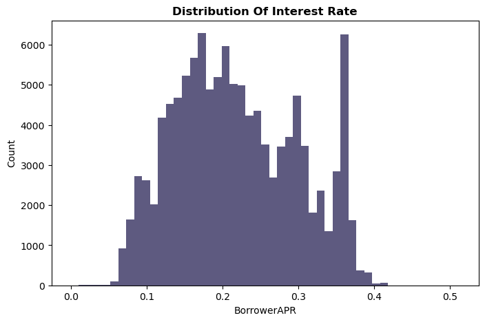

## Relationship Between BorrowerAPR And Loan Original Amount

> Although the interest rate range is large, there appears to be a negative correlation between the loan amount and the interest rate. The interest rate decreases with the increase in the loan amount.

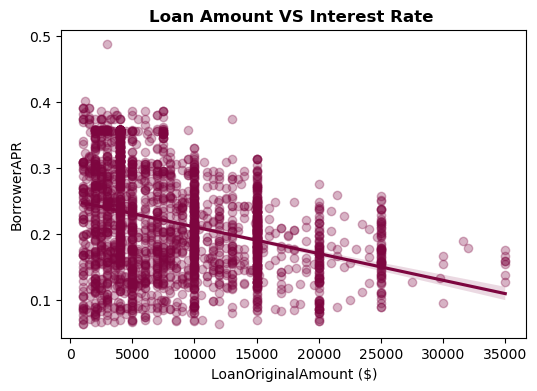

## The association between Employment status and Loan amount and Interest Rate.

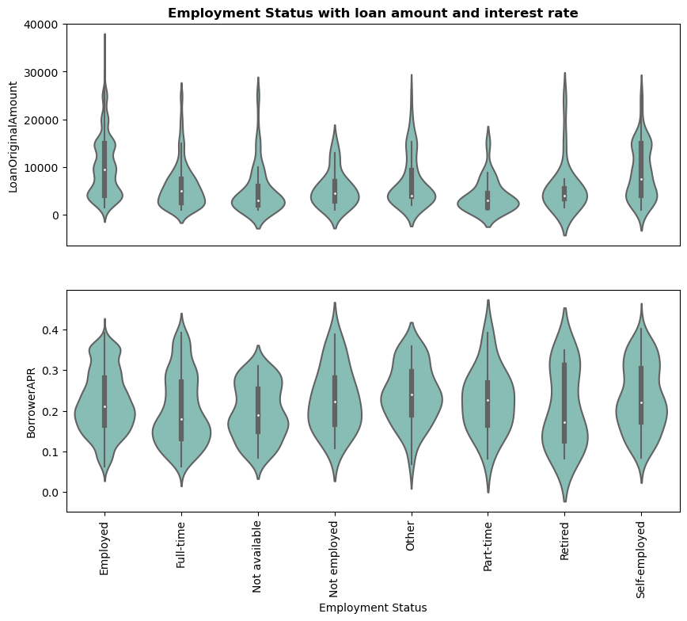

## The nature of the relationship between Loan original amount and Interest rate and Prosper score

> The relationship between the loan amount and the Prosper score is that an increase in the loan amount is accompanied by an increase in the Prosper score, which means a decrease in the risk score. But because there is a negative correlation between the interest rate and the loan amount, the interest rate will decrease as the loan amount increases

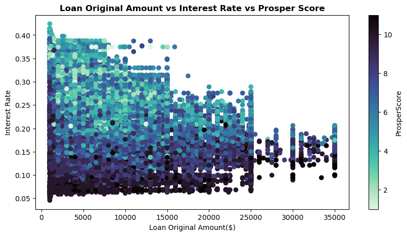

## Frequency of the Borrower State

> The states that have the biggest numbers of loans:  
> CA: California  
> TX: Texas  
> NY: New York  
> FL: Florida

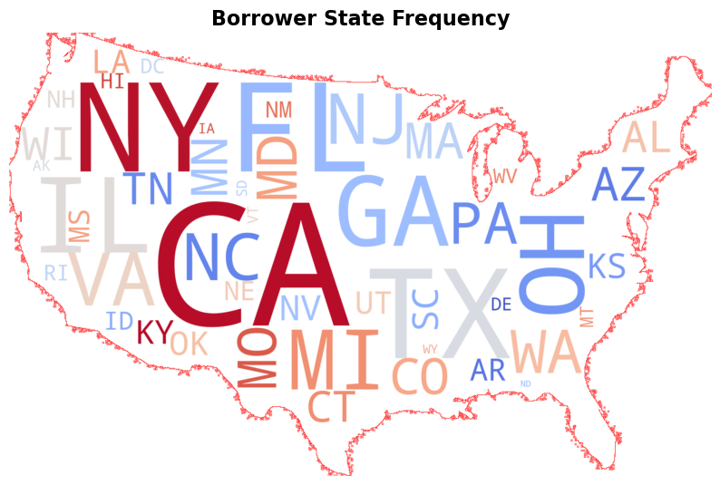

# Thank you for your attention